# SharkTank_Dataset

```python
import numpy as np
import pandas as pd
import matplotlib.pyplot as plt
import seaborn as sns
```

```python
# Load Data

df = pd.read_csv("shark_tank_dataset.csv")
df
```

|  | startup_name | domain | funding_amount | equity_offered | founders | stage | country | season | deal_status | investor |
| --- | --- | --- | --- | --- | --- | --- | --- | --- | --- | --- |
| 0 | InnoHub_0 | Fashion | NaN | unknown | Unknown | Series B | NaN | NaN | Funded | Namita |
| 1 | CloudLink_1 | logistics | 9839725.0 | NaN | 3 founders | Angel | USA | 6.0 | No Deal | Lori |
| 2 | GreenHub_2 | Agri | NaN | NaN | 2 founders | Series C | uae | 7.0 | Partially Funded | Barbara |
| 3 | UrbanBridge_3 | AI | NaN | NaN | 2 founders | Seed | uae | 3.0 | Funded | Peyush |
| 4 | BrightMart_4 | Tech | NaN | unknown | 3 founders | Series C | uae | 5.0 | Offer Withdrawn | Peyush |
| ... | ... | ... | ... | ... | ... | ... | ... | ... | ... | ... |
| 4995 | AISystems_4995 | Health | NaN | unknown | NaN | Series B | india | 5.0 | No Deal | Kevin |
| 4996 | MetaGen_4996 | food | 96965966.0 | NaN | NaN | Bootstrapped | uae | 4.0 | Rejected | Mark |
| 4997 | GreenBox_4997 | Logistics | NaN | 11.55% | NaN | Series B | usa | NaN | Funded | Mark |
| 4998 | MetaKart_4998 | edtech | 11280488.0 | unknown | NaN | Pre-Seed | Canada | 7.0 | Offer Withdrawn | Barbara |
| 4999 | FreshWave_4999 | AI | NaN | NaN | 2 founders | Pre-Seed | USA | 1.0 | Rejected | Mark |

5000 rows × 10 columns

# Data Exploration

- It helps data scientists understand the dataset, identify patterns, and gain insights before further analysis

```python
# It represent the number of rows and columns in the DataFrame
df.shape
```

```
(5000, 10)
```

```python
# To extract the column names of a DataFrame
df.columns.tolist()
```

```
['startup_name',
 'domain',
 'funding_amount',
 'equity_offered',
 'founders',
 'stage',
 'country',
 'season',
 'deal_status',
 'investor']
```

```python
# Prints information about the DataFrame
df.info()
```

```
<class 'pandas.core.frame.DataFrame'>
RangeIndex: 5000 entries, 0 to 4999
Data columns (total 10 columns):
 #   Column          Non-Null Count  Dtype
---  ------          --------------  -----
 0   startup_name    5000 non-null   object
 1   domain          4767 non-null   object
 2   funding_amount  1299 non-null   float64
 3   equity_offered  2500 non-null   object
 4   founders        3524 non-null   object
 5   stage           4369 non-null   object
 6   country         4500 non-null   object
 7   season          3867 non-null   float64
 8   deal_status     4178 non-null   object
 9   investor        4546 non-null   object
dtypes: float64(2), object(8)
memory usage: 390.8+ KB
```

**Unique**---> **Returns unique values from a data series**

```python
#Categorical

df["startup_name"].unique
```

```
<bound method Series.unique of 0            InnoHub_0
1          CloudLink_1
2           GreenHub_2
3        UrbanBridge_3
4         BrightMart_4
             ...
4995    AISystems_4995
4996      MetaGen_4996
4997     GreenBox_4997
4998     MetaKart_4998
4999    FreshWave_4999
Name: startup_name, Length: 5000, dtype: object>
```

```python
df["domain"].unique
```

```
<bound method Series.unique of 0         Fashion
1       logistics
2            Agri
3              AI
4            Tech
          ...
4995       Health
4996         food
4997    Logistics
4998       edtech
4999           AI
Name: domain, Length: 5000, dtype: object>
```

```python
df["domain"] = df["domain"].fillna("Unknown")
```

```python
#Categorical

df["domain"].unique
```

```
<bound method Series.unique of 0         Fashion
1       logistics
2            Agri
3              AI
4            Tech
          ...
4995       Health
4996         food
4997    Logistics
4998       edtech
4999           AI
Name: domain, Length: 5000, dtype: object>
```

```python
#continous

df["funding_amount"].unique()
```

```
array([      nan,  9839725., 31867562., ..., 15058242., 96965966.,
       11280488.])
```

**.replace is replaces whole values works with strings, numbers, lists, etc (all 25 value is changed in 39)**

**str.replace is works on entire column**

- (mr rahul ---> rahul,
- mr dev ----> dev,
- mr sonu ----> sonu )

```python
df["equity_offered"].unique
```

```
<bound method Series.unique of 0       unknown
1           NaN
2           NaN
3           NaN
4       unknown
         ...
4995    unknown
4996        NaN
4997     11.55%
4998    unknown
4999        NaN
Name: equity_offered, Length: 5000, dtype: object>
```

**Unknown” is for text (categorical) data.**

**NaN is for number (continuous) data.**

```python
# replace "unknown", "", "N/A" with nan

df["equity_offered"] = df["equity_offered"].replace(["unknown", "", "N/A"], np.nan)

# "unknown", empty "", and "N/A" and replace with nan (missing value).
```

```python
# Replace % to " "
# regex=False means treat % as a normal character
# errors="coerce" means if conversion fails, set it to NaN.

df["equity_offered"] = df["equity_offered"].str.replace("%", "", regex=False)  # regex = regular expression (Treat pattern as normal text)
df["equity_offered"] = pd.to_numeric(df["equity_offered"], errors="coerce") # Convert values to numbers (floats). If any value is not numeric, convert it to NaN.

# pd.to_numeric(..., errors="coerce")  ...........>  Convert to numbers(floats), invalid → nan
```

```python
# Continous

df["equity_offered"].unique()[:20]
```

```
array([  nan,  4.61, 49.58, 48.04, 48.71, 15.49, 25.97, 38.2 , 29.68,
       38.79, 47.35,  3.28, 39.86, 16.29, 11.39, 32.41,  8.64,  2.85,
       20.41, 32.66])
```

```python
df.loc[df["deal_status"] == "Rejected", "equity_offered"] = 0
```

```python
df["founders"].unique()
```

```
array(['Unknown', '3 founders', '2 founders', '4 founders', nan,
       '1 founder'], dtype=object)
```

```python
# Replace variations of unknown with NaN
df["founders"] = df["founders"].replace(["Unknown", "unknown", ""], np.nan)

# Extract the number from strings like "3 founders", "1 founder"
df["founders"] = df["founders"].str.extract(r'(\d+)').astype(float)
```

```python
df["founders"].unique()
```

```
array([nan,  3.,  2.,  4.,  1.])
```

```python
df["founders"] = df["founders"].astype("Int64")  # Pandas integer that supports NaN
```

```python
# count

df["founders"].unique()
```

```
<IntegerArray>
[<NA>, 3, 2, 4, 1]
Length: 5, dtype: Int64
```

```python
df["stage"].unique()
```

```
array(['Series B', 'Angel', 'Series C', 'Seed', 'Bootstrapped',
       'Pre-Seed', 'Series A', nan], dtype=object)
```

```python
stage_order = [
    "Bootstrapped",
    "Pre-seed",
    "Seed",
    "Angel",
    "Series A",
    "Series B",
    "Series C"
]

df["stage"] = pd.Categorical(df["stage"], categories=stage_order, ordered=True)
```

# Always replace NaN with "Unknown" for categorical columns before doing any crosstab or grouping — otherwise pandas will count nothing.

```python
df["stage"].unique()
```

```
['Series B', 'Angel', 'Series C', 'Seed', 'Bootstrapped', NaN, 'Series A']
Categories (7, object): ['Bootstrapped' < 'Pre-seed' < 'Seed' < 'Angel' < 'Series A' < 'Series B' < 'Series C']
```

```python
df["stage"] = df["stage"].cat.add_categories("Unknown")
df["stage"] = df["stage"].fillna("Unknown")
```

```python
# Categorical

df["stage"].unique()
```

```
['Series B', 'Angel', 'Series C', 'Seed', 'Bootstrapped', 'Unknown', 'Series A']
Categories (8, object): ['Bootstrapped' < 'Pre-seed' < 'Seed' < 'Angel' < 'Series A' < 'Series B' < 'Series C' < 'Unknown']
```

```python
df["country"].unique()
```

```
array([nan, 'USA', 'uae', 'india', 'India', 'canada', 'usa', 'Canada',
       'UAE', 'uk'], dtype=object)
```

```python
df["country"] = df["country"].str.lower()

df["country"] = df["country"].replace({
    "india": "India",
    "usa": "USA",
    "canada": "Canada",
    "uae": "UAE",
    "uk": "UK",
    "": np.nan
})

df["country"] = df["country"].fillna("Unknown")
```

```python
# Categorical

df["country"].unique()
```

```
array(['Unknown', 'USA', 'UAE', 'India', 'Canada', 'UK'], dtype=object)
```

```python
df["season"].unique()
```

```
array([nan,  6.,  7.,  3.,  5.,  1.,  2.,  4.])
```

```python
df["season"] = df["season"].astype("Int64")  # Pandas integer that supports NaN
```

```python
# count

df["season"].unique()
```

```
<IntegerArray>
[<NA>, 6, 7, 3, 5, 1, 2, 4]
Length: 8, dtype: Int64
```

```python
df["deal_status"].unique()
```

```
array(['Funded', 'No Deal', 'Partially Funded', 'Offer Withdrawn', nan,
       'Rejected'], dtype=object)
```

```python
df["deal_status"] = df["deal_status"].fillna("Unknown")
```

```python
# Categorical

df["deal_status"].unique()
```

```
array(['Funded', 'No Deal', 'Partially Funded', 'Offer Withdrawn',
       'Unknown', 'Rejected'], dtype=object)
```

```python
# Categorical

df["investor"].unique()
```

```
array(['Namita', 'Lori', 'Barbara', 'Peyush', nan, 'Aman', 'Ashneer',
       'Anupam', 'Vineeta', 'Kevin', 'Mark'], dtype=object)
```

```python
df["investor"] = df["investor"].fillna("Unknown")
```

```python
# Categorical

df["investor"].unique()
```

```
array(['Namita', 'Lori', 'Barbara', 'Peyush', 'Unknown', 'Aman',
       'Ashneer', 'Anupam', 'Vineeta', 'Kevin', 'Mark'], dtype=object)
```

**To check which is continous count And discrete**

```python
continous = ["funding_amount","equity_offered"]

# Count means No.of
count = ["founders","season"]

categorical = ["startup_name","domain","stage","country","deal_status","investor"]
```

**Generate descriptive statistics of a DataFrame**

```python
df[continous].describe()
```

|  | funding_amount | equity_offered |
| --- | --- | --- |
| count | 1.299000e+03 | 1896.000000 |
| mean | 4.989087e+07 | 17.073713 |
| std | 2.928822e+07 | 19.696373 |
| min | 1.908900e+04 | 0.000000 |
| 25% | 2.349381e+07 | 0.000000 |
| 50% | 4.911468e+07 | 7.295000 |
| 75% | 7.619417e+07 | 33.407500 |
| max | 9.996534e+07 | 59.890000 |

```python
pd.set_option('display.float_format', '{:,.0f}'.format)
```

```python
df[continous].describe()
```

|  | funding_amount | equity_offered |
| --- | --- | --- |
| count | 1,299 | 1,896 |
| mean | 49,890,874 | 17 |
| std | 29,288,218 | 20 |
| min | 19,089 | 0 |
| 25% | 23,493,808 | 0 |
| 50% | 49,114,685 | 7 |
| 75% | 76,194,172 | 33 |
| max | 99,965,336 | 60 |

```python
df[count].describe()
```

|  | founders | season |
| --- | --- | --- |
| count | 2,798 | 3,867 |
| mean | 2 | 4 |
| std | 1 | 2 |
| min | 1 | 1 |
| 25% | 1 | 2 |
| 50% | 2 | 4 |
| 75% | 3 | 6 |
| max | 4 | 7 |

**Top means Most common category**

**Freq means this is the number of times the top value appears**

```python
df[categorical].describe()
```

|  | startup_name | domain | stage | country | deal_status | investor |
| --- | --- | --- | --- | --- | --- | --- |
| count | 5000 | 5000 | 5000 | 5000 | 5000 | 5000 |
| unique | 5000 | 23 | 7 | 6 | 6 | 11 |
| top | InnoHub_0 | Agri | Unknown | India | Offer Withdrawn | Barbara |
| freq | 1 | 248 | 1289 | 1033 | 881 | 490 |

```python
# Check Missing value

df.isnull().sum()
```

```
startup_name         0
domain               0
funding_amount    3701
equity_offered    3104
founders          2202
stage                0
country              0
season            1133
deal_status          0
investor             0
dtype: int64
```

**Treat Missing values (NAN)**

```python
# Fill numeric columns logically
df["funding_amount"].fillna(df["funding_amount"].median(), inplace=True)
df["equity_offered"].fillna(df["equity_offered"].median(), inplace=True)
df["founders"].fillna(df["founders"].median(), inplace=True)
df["season"].fillna(df["season"].mode()[0], inplace=True)
```

```python
# Final check
df.isnull().sum()
```

```
startup_name      0
domain            0
funding_amount    0
equity_offered    0
founders          0
stage             0
country           0
season            0
deal_status       0
investor          0
dtype: int64
```

# skewness is only meaningful for numerical (continous or count) variables

```python
# calculates the skew for each column

df[continous].skew()
```

```
funding_amount   0
equity_offered   2
dtype: float64
```

```python
df[count].skew()
```

```
founders   1
season     1
dtype: Float64
```

```python
# To check duplicate

df.duplicated().sum()
```

```
0
```

**To check Outlier**

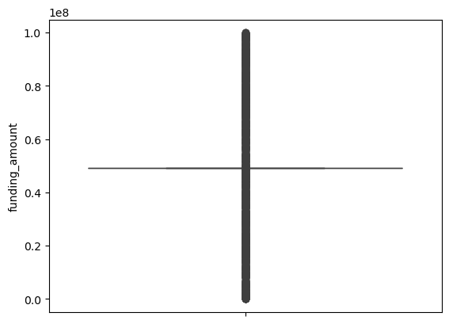

```python
sns.boxplot(df["funding_amount"])
plt.show()
```

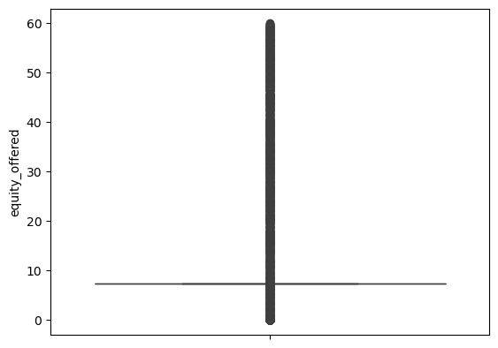

```python
sns.boxplot(df["equity_offered"])
plt.show()
```

# Data Cleaning

**Retrain the outliers (Keep them as it is) this is genuine data**

```python
# clean data

df
```

|  | startup_name | domain | funding_amount | equity_offered | founders | stage | country | season | deal_status | investor |
| --- | --- | --- | --- | --- | --- | --- | --- | --- | --- | --- |
| 0 | InnoHub_0 | Fashion | 49,114,685 | 7 | 2 | Series B | Unknown | 2 | Funded | Namita |
| 1 | CloudLink_1 | logistics | 9,839,725 | 7 | 3 | Angel | USA | 6 | No Deal | Lori |
| 2 | GreenHub_2 | Agri | 49,114,685 | 7 | 2 | Series C | UAE | 7 | Partially Funded | Barbara |
| 3 | UrbanBridge_3 | AI | 49,114,685 | 7 | 2 | Seed | UAE | 3 | Funded | Peyush |
| 4 | BrightMart_4 | Tech | 49,114,685 | 7 | 3 | Series C | UAE | 5 | Offer Withdrawn | Peyush |
| ... | ... | ... | ... | ... | ... | ... | ... | ... | ... | ... |
| 4995 | AISystems_4995 | Health | 49,114,685 | 7 | 2 | Series B | India | 5 | No Deal | Kevin |
| 4996 | MetaGen_4996 | food | 96,965,966 | 0 | 2 | Bootstrapped | UAE | 4 | Rejected | Mark |
| 4997 | GreenBox_4997 | Logistics | 49,114,685 | 12 | 2 | Series B | USA | 2 | Funded | Mark |
| 4998 | MetaKart_4998 | edtech | 11,280,488 | 7 | 2 | Unknown | Canada | 7 | Offer Withdrawn | Barbara |
| 4999 | FreshWave_4999 | AI | 49,114,685 | 0 | 2 | Unknown | USA | 1 | Rejected | Mark |

5000 rows × 10 columns

```python
df.head(10)
```

|  | startup_name | domain | funding_amount | equity_offered | founders | stage | country | season | deal_status | investor |
| --- | --- | --- | --- | --- | --- | --- | --- | --- | --- | --- |
| 0 | InnoHub_0 | Fashion | 49,114,685 | 7 | 2 | Series B | Unknown | 2 | Funded | Namita |
| 1 | CloudLink_1 | logistics | 9,839,725 | 7 | 3 | Angel | USA | 6 | No Deal | Lori |
| 2 | GreenHub_2 | Agri | 49,114,685 | 7 | 2 | Series C | UAE | 7 | Partially Funded | Barbara |
| 3 | UrbanBridge_3 | AI | 49,114,685 | 7 | 2 | Seed | UAE | 3 | Funded | Peyush |
| 4 | BrightMart_4 | Tech | 49,114,685 | 7 | 3 | Series C | UAE | 5 | Offer Withdrawn | Peyush |
| 5 | MetaSolutions_5 | Tech | 49,114,685 | 5 | 4 | Bootstrapped | India | 6 | Funded | Barbara |
| 6 | SmartNest_6 | fashion | 49,114,685 | 7 | 2 | Unknown | India | 2 | Funded | Namita |
| 7 | FreshNest_7 | fintech | 49,114,685 | 7 | 2 | Series A | India | 2 | Funded | Unknown |
| 8 | NextGrow_8 | ai | 49,114,685 | 50 | 3 | Seed | India | 1 | Funded | Aman |
| 9 | NextBridge_9 | Unknown | 49,114,685 | 48 | 2 | Unknown | India | 5 | Partially Funded | Unknown |

```python
df.tail(10)
```

|  | startup_name | domain | funding_amount | equity_offered | founders | stage | country | season | deal_status | investor |
| --- | --- | --- | --- | --- | --- | --- | --- | --- | --- | --- |
| 4990 | QuantumEdge_4990 | tech | 49,114,685 | 0 | 4 | Series A | UAE | 2 | Rejected | Aman |
| 4991 | FinGen_4991 | edtech | 85,870,599 | 7 | 2 | Unknown | UAE | 4 | Funded | Vineeta |
| 4992 | FreshFoods_4992 | food | 15,058,242 | 7 | 1 | Seed | UAE | 3 | No Deal | Mark |
| 4993 | MetaPulse_4993 | EdTech | 49,114,685 | 26 | 2 | Series B | UAE | 6 | Funded | Vineeta |
| 4994 | SmartKart_4994 | ai | 49,114,685 | 0 | 2 | Series C | UK | 3 | Rejected | Lori |
| 4995 | AISystems_4995 | Health | 49,114,685 | 7 | 2 | Series B | India | 5 | No Deal | Kevin |
| 4996 | MetaGen_4996 | food | 96,965,966 | 0 | 2 | Bootstrapped | UAE | 4 | Rejected | Mark |
| 4997 | GreenBox_4997 | Logistics | 49,114,685 | 12 | 2 | Series B | USA | 2 | Funded | Mark |
| 4998 | MetaKart_4998 | edtech | 11,280,488 | 7 | 2 | Unknown | Canada | 7 | Offer Withdrawn | Barbara |
| 4999 | FreshWave_4999 | AI | 49,114,685 | 0 | 2 | Unknown | USA | 1 | Rejected | Mark |

# Export DataFrames to CSV

- After cleaned data you can used in PowerBI or Tableau

```python
df.to_csv("sharktank_clean_dataset.csv",index=False)
```

# Data Analysis

- Measures + Plots
- Univariate, Bivariate, Multivariate

**Applying various questions or logics on dataset**

- value_counts() = To count the occurrences of each unique value within a specific column (or Series) of a Pandas DataFrame.
- describe() = Generates descriptive statistics of a DataFrame

**Univariate Measures + Plots**

**Measures**

**For continous**

```python
df["funding_amount"].describe()
```

```
count        5,000
mean    49,316,339
std     14,928,001
min         19,089
25%     49,114,685
50%     49,114,685
75%     49,114,685
max     99,965,336
Name: funding_amount, dtype: float64
```

```python
df["equity_offered"].describe()
```

```
count   5,000
mean       11
std        13
min         0
25%         7
50%         7
75%         7
max        60
Name: equity_offered, dtype: float64
```

**For count**

```python
df["founders"].value_counts()
```

```
founders
2    2908
1     702
3     700
4     690
Name: count, dtype: Int64
```

```python
df["season"].value_counts()
```

```
season
2    1733
3     573
6     558
1     542
4     538
7     534
5     522
Name: count, dtype: Int64
```

**FOR CATEGORICAL**

```python
df["startup_name"].value_counts()
```

```
startup_name
InnoHub_0             1
FreshNest_3330        1
HealthGen_3337        1
FoodSolutions_3336    1
GreenFoods_3335       1
                     ..
NextHub_1666          1
AgriBridge_1665       1
MetaKart_1664         1
QuantumFoods_1663     1
FreshWave_4999        1
Name: count, Length: 5000, dtype: int64
```

```python
df["domain"].value_counts()
```

```
domain
Agri          248
Tech          245
tech          242
Unknown       233
Fashion       226
Travel        225
fintech       224
Food          224
ecommerce     218
food          217
ai            214
agri          214
AI            214
E‑commerce    214
logistics     212
Logistics     212
health        209
travel        207
FinTech       205
edtech        203
Health        202
EdTech        200
fashion       192
Name: count, dtype: int64
```

```python
df["stage"].value_counts()
```

```
stage
Unknown         1289
Series B         662
Angel            638
Bootstrapped     623
Series A         614
Seed             595
Series C         579
Pre-seed           0
Name: count, dtype: int64
```

```python
df["country"].value_counts()
```

```
country
India      1033
Canada     1004
UAE         997
USA         989
Unknown     500
UK          477
Name: count, dtype: int64
```

```python
df["deal_status"].value_counts()
```

```
deal_status
Offer Withdrawn     881
Funded              875
Unknown             822
No Deal             821
Rejected            820
Partially Funded    781
Name: count, dtype: int64
```

```python
df["investor"].value_counts()
```

```
investor
Barbara    490
Lori       478
Ashneer    463
Mark       459
Unknown    454
Namita     453
Aman       449
Peyush     445
Vineeta    444
Kevin      433
Anupam     432
Name: count, dtype: int64
```

**Plots**

**UNIVARIATE PLOTS FOR CONTINOUS VARIABLE**

- HISTOGRAM
- KDE PLOT
- BOX PLOT

**Histogram**

**Used to create and display a histogram using the Seaborn and Matplotlib libraries**

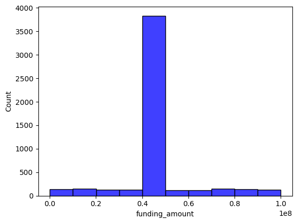

```python
# Create histogram
sns.histplot(df["funding_amount"], bins=10, color="blue", edgecolor="black")

plt.show()
```

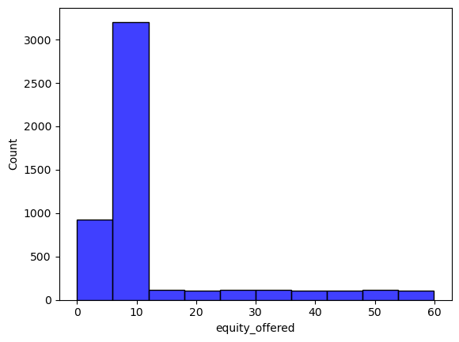

```python
# Create histogram
sns.histplot(df["equity_offered"], bins=10, color="blue", edgecolor="black")

plt.show()
```

**Kde plot**

**visualizes the probability density of a continuous variable**

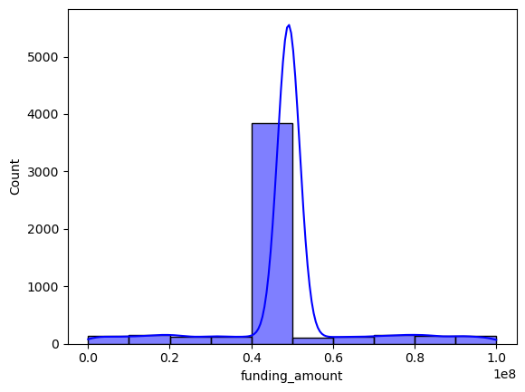

```python
sns.histplot(df["funding_amount"],bins = 10,color="blue", edgecolor="black",kde = True)
plt.show()
```

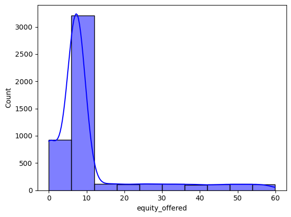

```python
sns.histplot(df["equity_offered"],bins = 10,color="blue", edgecolor="black",kde = True)
plt.show()
```

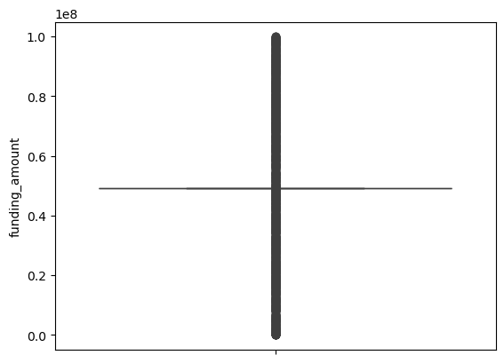

```python
sns.boxplot(df["funding_amount"])
plt.show()
```

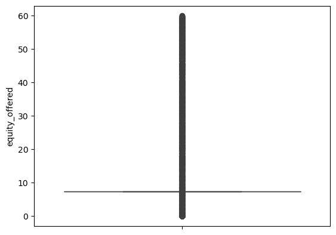

```python
sns.boxplot(df["equity_offered"])
plt.show()
```

**UNIVARIATE PLOTS FOR DISCRETE VARIABLE**

- COUNT PLOT
- PIE CHART

**Count Plot**

- Use: It shows the count of each category

**visually represents the counts or frequencies of observations within different categories of a categorical variable**

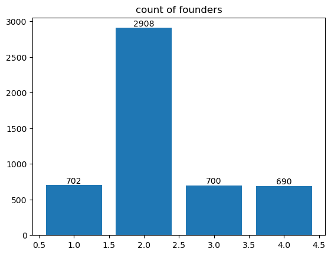

```python
patches = plt.bar(df["founders"].value_counts().index,df["founders"].value_counts())
plt.bar_label(patches)
plt.title("count of founders")
plt.show()
```

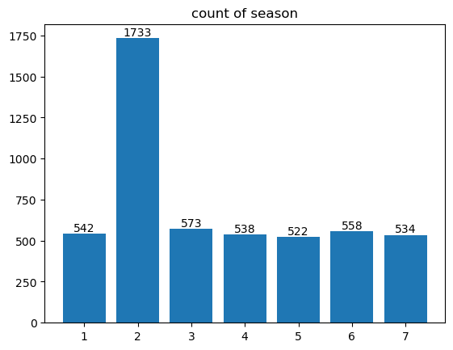

```python
patches = plt.bar(df["season"].value_counts().index,df["season"].value_counts())
plt.bar_label(patches)
plt.title("count of season")
plt.show()
```

**Categorical**

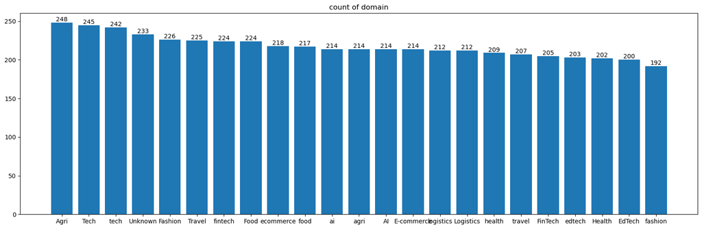

```python
plt.figure(figsize=(20, 6))

patches = plt.bar(df["domain"].value_counts().index,df["domain"].value_counts())
plt.bar_label(patches)
plt.title("count of domain")
plt.show()
```

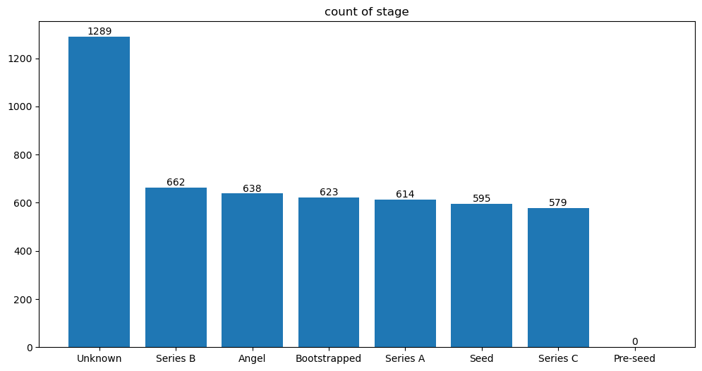

```python
plt.figure(figsize=(12, 6))

patches = plt.bar(df["stage"].value_counts().index,df["stage"].value_counts())
plt.bar_label(patches)
plt.title("count of stage")
plt.show()
```

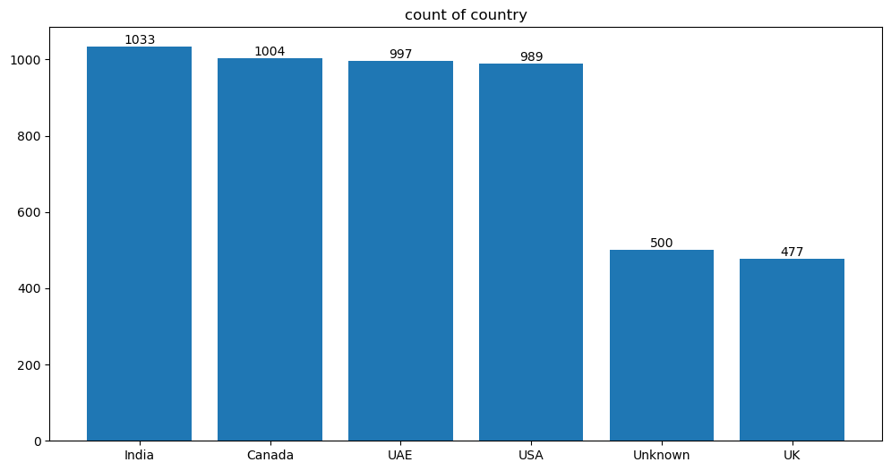

```python
plt.figure(figsize=(12, 6))

patches = plt.bar(df["country"].value_counts().index,df["country"].value_counts())
plt.bar_label(patches)
plt.title("count of country")
plt.show()
```

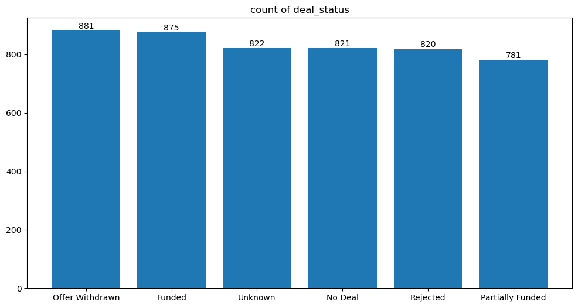

```python
plt.figure(figsize=(12, 6))

patches = plt.bar(df["deal_status"].value_counts().index,df["deal_status"].value_counts())
plt.bar_label(patches)
plt.title("count of deal_status")
plt.show()
```

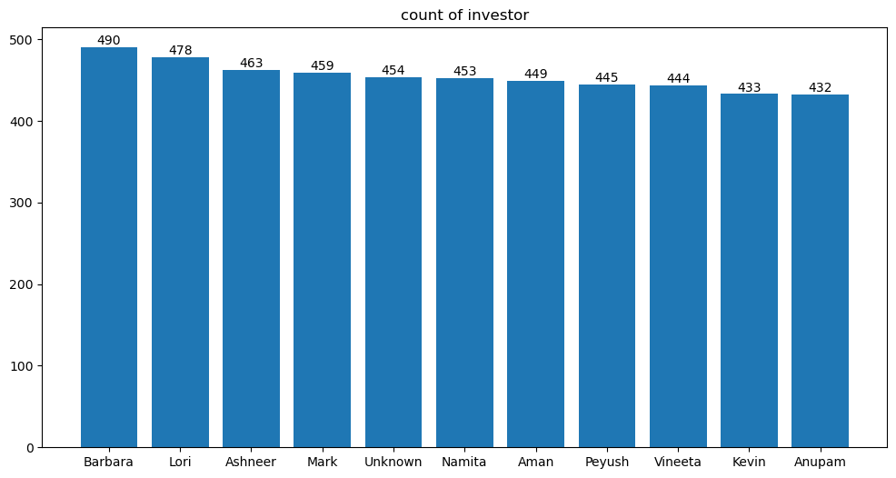

```python
plt.figure(figsize=(12, 6))

patches = plt.bar(df["investor"].value_counts().index,df["investor"].value_counts())
plt.bar_label(patches)
plt.title("count of investor")
plt.show()
```

**Pie Plot**

**is a circular statistical graphic that visualizes data proportions**

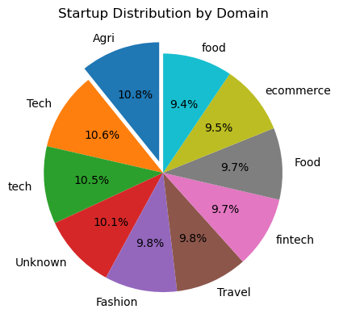

```python
d = df["domain"].value_counts().head(10)

plt.pie(d, labels=d.index, autopct="%0.1f%%", startangle=90, explode=[0.1]+[0]*9)
plt.title("Startup Distribution by Domain")
plt.show()
```

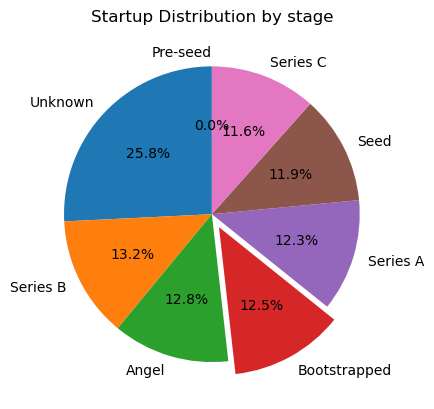

```python
d = df["stage"].value_counts()

plt.pie(d, labels=d.index, autopct="%0.1f%%", startangle=90, explode=[0,0,0,0.1,0,0,0,0])
plt.title("Startup Distribution by stage")
plt.show()
```

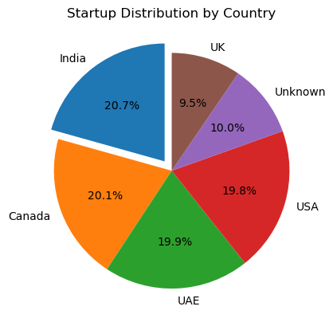

```python
d = df["country"].value_counts()

plt.pie(d, labels=d.index, autopct="%0.1f%%", startangle=90, explode=[0.1]+[0]*5)
plt.title("Startup Distribution by Country")
plt.show()
```

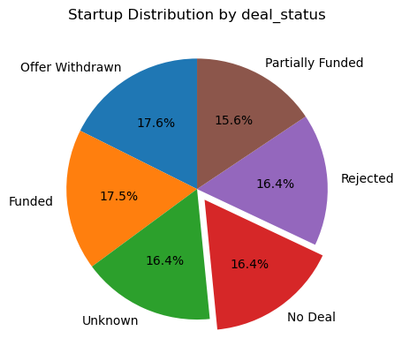

```python
d = df["deal_status"].value_counts()

plt.pie(d, labels=d.index, autopct="%0.1f%%", startangle=90, explode=[0,0,0,0.1,0,0])
plt.title("Startup Distribution by deal_status")
plt.show()
```

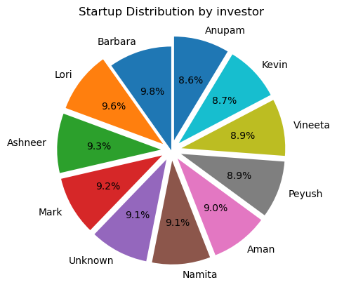

```python
d = df["investor"].value_counts()

plt.pie(d, labels=d.index, autopct="%0.1f%%", startangle=90, explode=[0]+[0.1]*10)
plt.title("Startup Distribution by investor")
plt.show()
```

# Bivariate Measures

- crosstab (2 discrete variable)
- correlation (Continuous + Continuous)
- groupby (1 discrete + 1 continous)

**Correlation**

- corr() is used to find the pairwise correlation of all columns in the Pandas Dataframe in Python

```python
df[continous].corr()
```

|  | funding_amount | equity_offered |
| --- | --- | --- |
| funding_amount | 1 | -0 |
| equity_offered | -0 | 1 |

**CrossTab**

- Cosstab returns the contingency table resulting from crossing two or more fields in a dataframe

```python
pd.crosstab(df["investor"], df["domain"], margins=True)
```

| domain investor | AI | Agri | EdTech | E‑commerce | Fashion | FinTech | Food | Health | Logistics | Tech | ... | ecommerce | edtech | fashion | fintech | food | health | logistics | tech | travel | All |
| --- | --- | --- | --- | --- | --- | --- | --- | --- | --- | --- | --- | --- | --- | --- | --- | --- | --- | --- | --- | --- | --- |
| Aman | 15 | 19 | 16 | 11 | 21 | 22 | 17 | 13 | 28 | 18 | ... | 18 | 17 | 20 | 21 | 21 | 21 | 14 | 31 | 19 | 449 |
| Anupam | 17 | 27 | 14 | 27 | 18 | 17 | 11 | 13 | 15 | 23 | ... | 14 | 17 | 17 | 17 | 13 | 22 | 24 | 19 | 16 | 432 |
| Ashneer | 17 | 22 | 17 | 21 | 22 | 21 | 22 | 18 | 18 | 25 | ... | 23 | 22 | 19 | 11 | 20 | 26 | 19 | 22 | 14 | 463 |
| Barbara | 17 | 25 | 25 | 19 | 29 | 19 | 28 | 30 | 26 | 22 | ... | 19 | 23 | 17 | 22 | 22 | 20 | 14 | 16 | 19 | 490 |
| Kevin | 18 | 22 | 19 | 20 | 19 | 14 | 25 | 22 | 17 | 22 | ... | 13 | 19 | 12 | 18 | 19 | 19 | 20 | 17 | 21 | 433 |
| Lori | 20 | 28 | 20 | 20 | 20 | 15 | 24 | 21 | 15 | 19 | ... | 27 | 18 | 14 | 35 | 19 | 24 | 24 | 24 | 18 | 478 |
| Mark | 27 | 22 | 16 | 18 | 16 | 22 | 28 | 23 | 21 | 20 | ... | 25 | 18 | 20 | 24 | 26 | 8 | 17 | 28 | 15 | 459 |
| Namita | 24 | 16 | 23 | 24 | 20 | 26 | 19 | 15 | 18 | 24 | ... | 21 | 16 | 18 | 16 | 21 | 20 | 16 | 26 | 18 | 453 |
| Peyush | 21 | 19 | 19 | 18 | 23 | 14 | 16 | 16 | 18 | 25 | ... | 19 | 13 | 14 | 20 | 21 | 13 | 21 | 17 | 20 | 445 |
| Unknown | 20 | 32 | 18 | 18 | 18 | 21 | 21 | 13 | 15 | 28 | ... | 13 | 18 | 21 | 22 | 20 | 17 | 22 | 24 | 19 | 454 |
| Vineeta | 18 | 16 | 13 | 18 | 20 | 14 | 13 | 18 | 21 | 19 | ... | 26 | 22 | 20 | 18 | 15 | 19 | 21 | 18 | 28 | 444 |
| All | 214 | 248 | 200 | 214 | 226 | 205 | 224 | 202 | 212 | 245 | ... | 218 | 203 | 192 | 224 | 217 | 209 | 212 | 242 | 207 | 5000 |

12 rows × 24 columns

```python
pd.crosstab(df["investor"], df["stage"], margins=True)
```

| stage investor | Bootstrapped | Seed | Angel | Series A | Series B | Series C | Unknown | All |
| --- | --- | --- | --- | --- | --- | --- | --- | --- |
| Aman | 49 | 40 | 67 | 63 | 60 | 53 | 117 | 449 |
| Anupam | 54 | 55 | 56 | 54 | 55 | 53 | 105 | 432 |
| Ashneer | 63 | 61 | 61 | 56 | 57 | 48 | 117 | 463 |
| Barbara | 64 | 53 | 64 | 66 | 64 | 51 | 128 | 490 |
| Kevin | 49 | 57 | 50 | 50 | 68 | 48 | 111 | 433 |
| Lori | 58 | 65 | 48 | 58 | 57 | 64 | 128 | 478 |
| Mark | 61 | 52 | 58 | 60 | 70 | 54 | 104 | 459 |
| Namita | 54 | 54 | 46 | 49 | 63 | 52 | 135 | 453 |
| Peyush | 56 | 62 | 58 | 51 | 56 | 50 | 112 | 445 |
| Unknown | 54 | 47 | 60 | 59 | 49 | 65 | 120 | 454 |
| Vineeta | 61 | 49 | 70 | 48 | 63 | 41 | 112 | 444 |
| All | 623 | 595 | 638 | 614 | 662 | 579 | 1289 | 5000 |

```python
pd.crosstab(df["investor"], df["country"], margins=True)
```

| country investor | Canada | India | UAE | UK | USA | Unknown | All |
| --- | --- | --- | --- | --- | --- | --- | --- |
| Aman | 92 | 86 | 89 | 41 | 84 | 57 | 449 |
| Anupam | 90 | 98 | 94 | 34 | 83 | 33 | 432 |
| Ashneer | 90 | 102 | 95 | 48 | 84 | 44 | 463 |
| Barbara | 100 | 111 | 93 | 40 | 106 | 40 | 490 |
| Kevin | 95 | 83 | 93 | 41 | 85 | 36 | 433 |
| Lori | 93 | 93 | 90 | 56 | 92 | 54 | 478 |
| Mark | 83 | 97 | 84 | 39 | 104 | 52 | 459 |
| Namita | 108 | 87 | 97 | 30 | 82 | 49 | 453 |
| Peyush | 82 | 82 | 98 | 43 | 87 | 53 | 445 |
| Unknown | 93 | 95 | 80 | 57 | 87 | 42 | 454 |
| Vineeta | 78 | 99 | 84 | 48 | 95 | 40 | 444 |
| All | 1004 | 1033 | 997 | 477 | 989 | 500 | 5000 |

```python
pd.crosstab(df["investor"], df["deal_status"], margins=True)
```

| deal_status investor | Funded | No Deal | Offer Withdrawn | Partially Funded | Rejected | Unknown | All |
| --- | --- | --- | --- | --- | --- | --- | --- |
| Aman | 76 | 75 | 73 | 75 | 79 | 71 | 449 |
| Anupam | 74 | 67 | 76 | 67 | 80 | 68 | 432 |
| Ashneer | 88 | 71 | 89 | 72 | 74 | 69 | 463 |
| Barbara | 88 | 80 | 90 | 77 | 65 | 90 | 490 |
| Kevin | 77 | 82 | 66 | 57 | 82 | 69 | 433 |
| Lori | 72 | 79 | 81 | 81 | 71 | 94 | 478 |
| Mark | 84 | 79 | 78 | 71 | 75 | 72 | 459 |
| Namita | 79 | 77 | 84 | 66 | 81 | 66 | 453 |
| Peyush | 74 | 71 | 85 | 59 | 74 | 82 | 445 |
| Unknown | 80 | 72 | 82 | 76 | 72 | 72 | 454 |
| Vineeta | 83 | 68 | 77 | 80 | 67 | 69 | 444 |
| All | 875 | 821 | 881 | 781 | 820 | 822 | 5000 |

**If you want to see proportions (percentages):**

```python
pd.crosstab(df["investor"], df["deal_status"], normalize="index") * 100
```

| deal_status investor | Funded | No Deal | Offer Withdrawn | Partially Funded | Rejected | Unknown |
| --- | --- | --- | --- | --- | --- | --- |
| Aman | 17 | 17 | 16 | 17 | 18 | 16 |
| Anupam | 17 | 16 | 18 | 16 | 19 | 16 |
| Ashneer | 19 | 15 | 19 | 16 | 16 | 15 |
| Barbara | 18 | 16 | 18 | 16 | 13 | 18 |
| Kevin | 18 | 19 | 15 | 13 | 19 | 16 |
| Lori | 15 | 17 | 17 | 17 | 15 | 20 |
| Mark | 18 | 17 | 17 | 15 | 16 | 16 |
| Namita | 17 | 17 | 19 | 15 | 18 | 15 |
| Peyush | 17 | 16 | 19 | 13 | 17 | 18 |
| Unknown | 18 | 16 | 18 | 17 | 16 | 16 |
| Vineeta | 19 | 15 | 17 | 18 | 15 | 16 |

**Group By**

- Groupby separate identical data into groups to allow for further aggregation and analysis

```python
df.groupby("startup_name")["funding_amount"].describe().T
```

| startup_name | AIBox_1247 | AIBox_1825 | AIBox_1855 | AIBox_2035 | AIBox_2054 | AIBox_2259 | AIBox_2448 | AIBox_2939 | AIBox_3244 | AIBox_3659 | ... | UrbanWave_4093 | UrbanWave_4182 | UrbanWave_983 | UrbanWorks_1528 | UrbanWorks_1674 | UrbanWorks_1977 | UrbanWorks_3342 | UrbanWorks_3379 | UrbanWorks_3747 | UrbanWorks_3772 |
| --- | --- | --- | --- | --- | --- | --- | --- | --- | --- | --- | --- | --- | --- | --- | --- | --- | --- | --- | --- | --- | --- |
| count | 1 | 1 | 1 | 1 | 1 | 1 | 1 | 1 | 1 | 1 | ... | 1 | 1 | 1 | 1 | 1 | 1 | 1 | 1 | 1 | 1 |
| mean | 94,477,539 | 49,114,685 | 32,617,072 | 49,114,685 | 49,114,685 | 49,114,685 | 82,414,357 | 49,114,685 | 49,114,685 | 49,114,685 | ... | 49,114,685 | 49,114,685 | 49,114,685 | 8,365,089 | 49,114,685 | 49,114,685 | 49,114,685 | 49,114,685 | 49,114,685 | 50,193,213 |
| std | NaN | NaN | NaN | NaN | NaN | NaN | NaN | NaN | NaN | NaN | ... | NaN | NaN | NaN | NaN | NaN | NaN | NaN | NaN | NaN | NaN |
| min | 94,477,539 | 49,114,685 | 32,617,072 | 49,114,685 | 49,114,685 | 49,114,685 | 82,414,357 | 49,114,685 | 49,114,685 | 49,114,685 | ... | 49,114,685 | 49,114,685 | 49,114,685 | 8,365,089 | 49,114,685 | 49,114,685 | 49,114,685 | 49,114,685 | 49,114,685 | 50,193,213 |
| 25% | 94,477,539 | 49,114,685 | 32,617,072 | 49,114,685 | 49,114,685 | 49,114,685 | 82,414,357 | 49,114,685 | 49,114,685 | 49,114,685 | ... | 49,114,685 | 49,114,685 | 49,114,685 | 8,365,089 | 49,114,685 | 49,114,685 | 49,114,685 | 49,114,685 | 49,114,685 | 50,193,213 |
| 50% | 94,477,539 | 49,114,685 | 32,617,072 | 49,114,685 | 49,114,685 | 49,114,685 | 82,414,357 | 49,114,685 | 49,114,685 | 49,114,685 | ... | 49,114,685 | 49,114,685 | 49,114,685 | 8,365,089 | 49,114,685 | 49,114,685 | 49,114,685 | 49,114,685 | 49,114,685 | 50,193,213 |
| 75% | 94,477,539 | 49,114,685 | 32,617,072 | 49,114,685 | 49,114,685 | 49,114,685 | 82,414,357 | 49,114,685 | 49,114,685 | 49,114,685 | ... | 49,114,685 | 49,114,685 | 49,114,685 | 8,365,089 | 49,114,685 | 49,114,685 | 49,114,685 | 49,114,685 | 49,114,685 | 50,193,213 |
| max | 94,477,539 | 49,114,685 | 32,617,072 | 49,114,685 | 49,114,685 | 49,114,685 | 82,414,357 | 49,114,685 | 49,114,685 | 49,114,685 | ... | 49,114,685 | 49,114,685 | 49,114,685 | 8,365,089 | 49,114,685 | 49,114,685 | 49,114,685 | 49,114,685 | 49,114,685 | 50,193,213 |

8 rows × 5000 columns

```python
df.groupby("domain")["funding_amount"].describe().T
```

| domain | AI | Agri | EdTech | E‑commerce | Fashion | FinTech | Food | Health | Logistics | Tech | ... | ai | ecommerce | edtech | fashion | fintech | food | health | logistics | tech | travel |
| --- | --- | --- | --- | --- | --- | --- | --- | --- | --- | --- | --- | --- | --- | --- | --- | --- | --- | --- | --- | --- | --- |
| count | 214 | 248 | 200 | 214 | 226 | 205 | 224 | 202 | 212 | 245 | ... | 214 | 218 | 203 | 192 | 224 | 217 | 209 | 212 | 242 | 207 |
| mean | 47,249,266 | 48,942,867 | 49,620,698 | 49,498,481 | 48,685,602 | 45,856,652 | 49,256,378 | 50,871,661 | 46,598,498 | 49,478,645 | ... | 49,869,043 | 49,509,444 | 48,695,663 | 47,972,390 | 49,634,169 | 48,331,854 | 49,726,884 | 51,185,363 | 50,940,207 | 51,478,471 |
| std | 14,615,753 | 14,764,323 | 13,718,598 | 13,969,906 | 13,290,577 | 14,840,527 | 13,343,737 | 14,883,500 | 13,972,291 | 14,308,929 | ... | 15,769,281 | 15,641,721 | 16,623,624 | 15,686,311 | 13,992,791 | 13,868,502 | 15,804,620 | 17,322,599 | 17,276,753 | 14,449,683 |
| min | 1,032,192 | 203,969 | 394,038 | 106,075 | 4,147,173 | 285,251 | 128,510 | 2,724,499 | 500,254 | 1,147,872 | ... | 1,810,637 | 498,126 | 1,958,965 | 223,111 | 1,663,836 | 1,286,894 | 372,995 | 19,089 | 813,173 | 998,303 |
| 25% | 49,114,685 | 49,114,685 | 49,114,685 | 49,114,685 | 49,114,685 | 49,114,685 | 49,114,685 | 49,114,685 | 49,114,685 | 49,114,685 | ... | 49,114,685 | 49,114,685 | 49,114,685 | 49,114,685 | 49,114,685 | 49,114,685 | 49,114,685 | 49,114,685 | 49,114,685 | 49,114,685 |
| 50% | 49,114,685 | 49,114,685 | 49,114,685 | 49,114,685 | 49,114,685 | 49,114,685 | 49,114,685 | 49,114,685 | 49,114,685 | 49,114,685 | ... | 49,114,685 | 49,114,685 | 49,114,685 | 49,114,685 | 49,114,685 | 49,114,685 | 49,114,685 | 49,114,685 | 49,114,685 | 49,114,685 |
| 75% | 49,114,685 | 49,114,685 | 49,114,685 | 49,114,685 | 49,114,685 | 49,114,685 | 49,114,685 | 49,114,685 | 49,114,685 | 49,114,685 | ... | 49,114,685 | 49,114,685 | 49,114,685 | 49,114,685 | 49,114,685 | 49,114,685 | 49,114,685 | 49,114,685 | 49,114,685 | 49,114,685 |
| max | 99,223,531 | 98,169,786 | 97,772,241 | 98,845,729 | 98,669,891 | 99,948,211 | 94,129,469 | 98,859,787 | 99,474,284 | 99,950,959 | ... | 97,853,918 | 99,698,789 | 98,783,538 | 97,039,592 | 99,200,937 | 97,451,791 | 98,829,135 | 99,369,892 | 99,965,336 | 99,707,818 |

8 rows × 23 columns

```python
df.groupby("stage")["funding_amount"].describe().T
```

| stage | Bootstrapped | Pre-seed | Seed | Angel | Series A | Series B | Series C | Unknown |
| --- | --- | --- | --- | --- | --- | --- | --- | --- |
| count | 623 | 0 | 595 | 638 | 614 | 662 | 579 | 1,289 |
| mean | 50,129,787 | NaN | 47,788,696 | 48,774,616 | 49,343,368 | 48,970,393 | 49,900,248 | 49,798,981 |
| std | 14,657,350 | NaN | 15,665,005 | 13,881,888 | 15,351,101 | 15,422,852 | 14,183,466 | 15,039,521 |
| min | 203,969 | NaN | 106,075 | 19,089 | 29,030 | 177,420 | 128,510 | 285,251 |
| 25% | 49,114,685 | NaN | 49,114,685 | 49,114,685 | 49,114,685 | 49,114,685 | 49,114,685 | 49,114,685 |
| 50% | 49,114,685 | NaN | 49,114,685 | 49,114,685 | 49,114,685 | 49,114,685 | 49,114,685 | 49,114,685 |
| 75% | 49,114,685 | NaN | 49,114,685 | 49,114,685 | 49,114,685 | 49,114,685 | 49,114,685 | 49,114,685 |
| max | 99,674,401 | NaN | 98,829,135 | 99,707,818 | 99,698,789 | 99,965,336 | 99,948,211 | 99,781,776 |

```python
df.groupby("country")["funding_amount"].describe().T
```

| country | Canada | India | UAE | UK | USA | Unknown |
| --- | --- | --- | --- | --- | --- | --- |
| count | 1,004 | 1,033 | 997 | 477 | 989 | 500 |
| mean | 49,353,495 | 49,391,704 | 48,867,411 | 50,389,367 | 49,382,048 | 48,827,548 |
| std | 14,366,021 | 14,944,605 | 14,335,554 | 15,873,133 | 15,500,549 | 15,090,325 |
| min | 498,126 | 19,089 | 106,075 | 203,969 | 128,510 | 223,111 |
| 25% | 49,114,685 | 49,114,685 | 49,114,685 | 49,114,685 | 49,114,685 | 49,114,685 |
| 50% | 49,114,685 | 49,114,685 | 49,114,685 | 49,114,685 | 49,114,685 | 49,114,685 |
| 75% | 49,114,685 | 49,114,685 | 49,114,685 | 49,114,685 | 49,114,685 | 49,114,685 |
| max | 99,948,211 | 99,707,818 | 99,965,336 | 99,950,959 | 99,369,892 | 99,223,531 |

```python
df.groupby("deal_status")["funding_amount"].describe().T
```

| deal_status | Funded | No Deal | Offer Withdrawn | Partially Funded | Rejected | Unknown |
| --- | --- | --- | --- | --- | --- | --- |
| count | 875 | 821 | 881 | 781 | 820 | 822 |
| mean | 49,712,416 | 48,484,638 | 48,888,635 | 49,863,201 | 49,502,095 | 49,478,926 |
| std | 14,161,802 | 15,191,389 | 14,486,363 | 14,978,527 | 15,493,605 | 15,294,757 |
| min | 177,420 | 128,510 | 106,075 | 29,030 | 285,251 | 19,089 |
| 25% | 49,114,685 | 49,114,685 | 49,114,685 | 49,114,685 | 49,114,685 | 49,114,685 |
| 50% | 49,114,685 | 49,114,685 | 49,114,685 | 49,114,685 | 49,114,685 | 49,114,685 |
| 75% | 49,114,685 | 49,114,685 | 49,114,685 | 49,114,685 | 49,114,685 | 49,114,685 |
| max | 99,965,336 | 98,383,186 | 99,950,959 | 99,369,892 | 99,474,284 | 99,707,818 |

```python
df.groupby("investor")["funding_amount"].describe().T
```

| investor | Aman | Anupam | Ashneer | Barbara | Kevin | Lori | Mark | Namita | Peyush | Unknown | Vineeta |
| --- | --- | --- | --- | --- | --- | --- | --- | --- | --- | --- | --- |
| count | 449 | 432 | 463 | 490 | 433 | 478 | 459 | 453 | 445 | 454 | 444 |
| mean | 48,658,004 | 49,134,542 | 48,641,630 | 49,045,526 | 50,018,240 | 48,694,201 | 48,940,495 | 49,518,790 | 49,507,213 | 50,227,665 | 50,205,522 |
| std | 16,228,795 | 15,609,212 | 15,102,020 | 15,137,877 | 13,395,866 | 14,122,156 | 14,954,017 | 16,592,673 | 14,289,131 | 13,919,796 | 14,562,710 |
| min | 813,173 | 394,038 | 285,251 | 203,969 | 2,315,681 | 177,420 | 106,075 | 223,111 | 629,910 | 535,595 | 19,089 |
| 25% | 49,114,685 | 49,114,685 | 49,114,685 | 49,114,685 | 49,114,685 | 49,114,685 | 49,114,685 | 49,114,685 | 49,114,685 | 49,114,685 | 49,114,685 |
| 50% | 49,114,685 | 49,114,685 | 49,114,685 | 49,114,685 | 49,114,685 | 49,114,685 | 49,114,685 | 49,114,685 | 49,114,685 | 49,114,685 | 49,114,685 |
| 75% | 49,114,685 | 49,114,685 | 49,114,685 | 49,114,685 | 49,114,685 | 49,114,685 | 49,114,685 | 49,114,685 | 49,114,685 | 49,114,685 | 49,114,685 |
| max | 99,369,892 | 99,707,818 | 98,190,264 | 99,674,401 | 99,965,336 | 99,948,211 | 98,115,705 | 99,781,776 | 98,669,891 | 99,223,531 | 99,950,959 |

```python
df.groupby("startup_name")["equity_offered"].describe().T
```

| startup_name | AIBox_1247 | AIBox_1825 | AIBox_1855 | AIBox_2035 | AIBox_2054 | AIBox_2259 | AIBox_2448 | AIBox_2939 | AIBox_3244 | AIBox_3659 | ... | UrbanWave_4093 | UrbanWave_4182 | UrbanWave_983 | UrbanWorks_1528 | UrbanWorks_1674 | UrbanWorks_1977 | UrbanWorks_3342 | UrbanWorks_3379 | UrbanWorks_3747 | UrbanWorks_3772 |
| --- | --- | --- | --- | --- | --- | --- | --- | --- | --- | --- | --- | --- | --- | --- | --- | --- | --- | --- | --- | --- | --- |
| count | 1 | 1 | 1 | 1 | 1 | 1 | 1 | 1 | 1 | 1 | ... | 1 | 1 | 1 | 1 | 1 | 1 | 1 | 1 | 1 | 1 |
| mean | 7 | 7 | 7 | 7 | 7 | 24 | 7 | 19 | 7 | 0 | ... | 7 | 7 | 7 | 0 | 7 | 7 | 7 | 3 | 0 | 7 |
| std | NaN | NaN | NaN | NaN | NaN | NaN | NaN | NaN | NaN | NaN | ... | NaN | NaN | NaN | NaN | NaN | NaN | NaN | NaN | NaN | NaN |
| min | 7 | 7 | 7 | 7 | 7 | 24 | 7 | 19 | 7 | 0 | ... | 7 | 7 | 7 | 0 | 7 | 7 | 7 | 3 | 0 | 7 |
| 25% | 7 | 7 | 7 | 7 | 7 | 24 | 7 | 19 | 7 | 0 | ... | 7 | 7 | 7 | 0 | 7 | 7 | 7 | 3 | 0 | 7 |
| 50% | 7 | 7 | 7 | 7 | 7 | 24 | 7 | 19 | 7 | 0 | ... | 7 | 7 | 7 | 0 | 7 | 7 | 7 | 3 | 0 | 7 |
| 75% | 7 | 7 | 7 | 7 | 7 | 24 | 7 | 19 | 7 | 0 | ... | 7 | 7 | 7 | 0 | 7 | 7 | 7 | 3 | 0 | 7 |
| max | 7 | 7 | 7 | 7 | 7 | 24 | 7 | 19 | 7 | 0 | ... | 7 | 7 | 7 | 0 | 7 | 7 | 7 | 3 | 0 | 7 |

8 rows × 5000 columns

```python
df.groupby("domain")["equity_offered"].describe().T
```

| domain | AI | Agri | EdTech | E‑commerce | Fashion | FinTech | Food | Health | Logistics | Tech | ... | ai | ecommerce | edtech | fashion | fintech | food | health | logistics | tech | travel |
| --- | --- | --- | --- | --- | --- | --- | --- | --- | --- | --- | --- | --- | --- | --- | --- | --- | --- | --- | --- | --- | --- |
| count | 214 | 248 | 200 | 214 | 226 | 205 | 224 | 202 | 212 | 245 | ... | 214 | 218 | 203 | 192 | 224 | 217 | 209 | 212 | 242 | 207 |
| mean | 11 | 10 | 11 | 12 | 10 | 12 | 11 | 10 | 12 | 12 | ... | 11 | 9 | 11 | 11 | 12 | 12 | 11 | 11 | 11 | 11 |
| std | 12 | 11 | 13 | 15 | 11 | 14 | 13 | 11 | 14 | 15 | ... | 12 | 12 | 14 | 14 | 14 | 13 | 13 | 13 | 12 | 12 |
| min | 0 | 0 | 0 | 0 | 0 | 0 | 0 | 0 | 0 | 0 | ... | 0 | 0 | 0 | 0 | 0 | 0 | 0 | 0 | 0 | 0 |
| 25% | 7 | 7 | 7 | 7 | 7 | 7 | 7 | 7 | 7 | 7 | ... | 7 | 7 | 7 | 7 | 7 | 7 | 7 | 7 | 7 | 7 |
| 50% | 7 | 7 | 7 | 7 | 7 | 7 | 7 | 7 | 7 | 7 | ... | 7 | 7 | 7 | 7 | 7 | 7 | 7 | 7 | 7 | 7 |
| 75% | 7 | 7 | 7 | 7 | 7 | 7 | 7 | 7 | 7 | 7 | ... | 7 | 7 | 7 | 7 | 7 | 7 | 7 | 7 | 7 | 7 |
| max | 59 | 57 | 59 | 58 | 58 | 57 | 57 | 54 | 59 | 60 | ... | 58 | 59 | 59 | 60 | 59 | 59 | 57 | 57 | 59 | 60 |

8 rows × 23 columns

```python
df.groupby("stage")["equity_offered"].describe().T
```

| stage | Bootstrapped | Pre-seed | Seed | Angel | Series A | Series B | Series C | Unknown |
| --- | --- | --- | --- | --- | --- | --- | --- | --- |
| count | 623 | 0 | 595 | 638 | 614 | 662 | 579 | 1,289 |
| mean | 11 | NaN | 11 | 11 | 11 | 11 | 11 | 11 |
| std | 13 | NaN | 13 | 13 | 14 | 13 | 12 | 13 |
| min | 0 | NaN | 0 | 0 | 0 | 0 | 0 | 0 |
| 25% | 7 | NaN | 7 | 7 | 7 | 7 | 7 | 7 |
| 50% | 7 | NaN | 7 | 7 | 7 | 7 | 7 | 7 |
| 75% | 7 | NaN | 7 | 7 | 7 | 7 | 7 | 7 |
| max | 59 | NaN | 60 | 60 | 59 | 59 | 59 | 60 |

```python
df.groupby("country")["equity_offered"].describe().T
```

| country | Canada | India | UAE | UK | USA | Unknown |
| --- | --- | --- | --- | --- | --- | --- |
| count | 1,004 | 1,033 | 997 | 477 | 989 | 500 |
| mean | 11 | 11 | 11 | 11 | 11 | 11 |
| std | 13 | 13 | 14 | 13 | 13 | 14 |
| min | 0 | 0 | 0 | 0 | 0 | 0 |
| 25% | 7 | 7 | 7 | 7 | 7 | 7 |
| 50% | 7 | 7 | 7 | 7 | 7 | 7 |
| 75% | 7 | 7 | 7 | 7 | 7 | 7 |
| max | 59 | 60 | 59 | 60 | 60 | 59 |

```python
df.groupby("deal_status")["equity_offered"].describe().T
```

| deal_status | Funded | No Deal | Offer Withdrawn | Partially Funded | Rejected | Unknown |
| --- | --- | --- | --- | --- | --- | --- |
| count | 875 | 821 | 881 | 781 | 820 | 822 |
| mean | 13 | 12 | 14 | 13 | 0 | 13 |
| std | 13 | 13 | 14 | 13 | 0 | 13 |
| min | 1 | 1 | 1 | 1 | 0 | 1 |
| 25% | 7 | 7 | 7 | 7 | 0 | 7 |
| 50% | 7 | 7 | 7 | 7 | 0 | 7 |
| 75% | 7 | 7 | 7 | 7 | 0 | 7 |
| max | 59 | 60 | 60 | 60 | 0 | 60 |

```python
df.groupby("investor")["equity_offered"].describe().T
```

| investor | Aman | Anupam | Ashneer | Barbara | Kevin | Lori | Mark | Namita | Peyush | Unknown | Vineeta |
| --- | --- | --- | --- | --- | --- | --- | --- | --- | --- | --- | --- |
| count | 449 | 432 | 463 | 490 | 433 | 478 | 459 | 453 | 445 | 454 | 444 |
| mean | 11 | 11 | 12 | 11 | 10 | 12 | 12 | 11 | 10 | 11 | 11 |
| std | 13 | 13 | 14 | 13 | 12 | 14 | 14 | 13 | 11 | 13 | 13 |
| min | 0 | 0 | 0 | 0 | 0 | 0 | 0 | 0 | 0 | 0 | 0 |
| 25% | 7 | 7 | 7 | 7 | 7 | 7 | 7 | 7 | 7 | 7 | 7 |
| 50% | 7 | 7 | 7 | 7 | 7 | 7 | 7 | 7 | 7 | 7 | 7 |
| 75% | 7 | 7 | 7 | 7 | 7 | 7 | 7 | 7 | 7 | 7 | 7 |
| max | 60 | 60 | 60 | 60 | 59 | 59 | 59 | 57 | 59 | 58 | 60 |

# Bivariate Plots

- SCATTER PLOT
- BAR PLOT
- JOINT PLOT
- HEAT MAP

**Scatter Plot**

- A scatter plot in Python is a type of data visualization that uses dots to represent values for two different numeric variables
- Marking the data points on the graph
- 2 continous

**USE:** To check 1.linearity,2.Direction,3.Strength

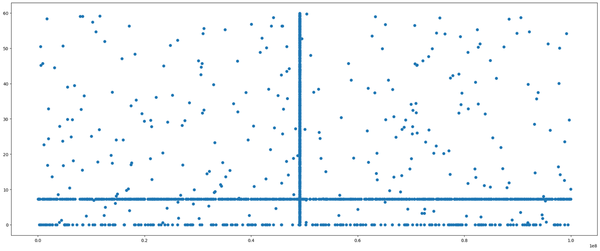

```python
plt.figure(figsize=(25,10))

plt.scatter(x=df["funding_amount"],y=df["equity_offered"])
plt.show()
```

**Joint Plot**

- joint plot visualizes the relationship between two variables along with their individual distributions

**Use:** Combination of Scatter plot and Histogram

- A join plot allows to study the relationship between 2 numeric variables.

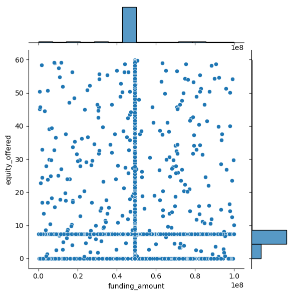

```python
sns.jointplot(x="funding_amount",y="equity_offered",data=df)
plt.show()
```

**Bar plot**

- is a data visualization tool used to represent categorical data with rectangular bars

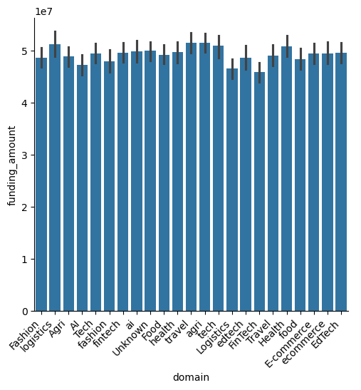

```python
sns.catplot(x="domain",y="funding_amount",data=df,kind="bar")
plt.xticks(rotation=45, ha='right')  # Rotate x-axis labels for readability
plt.show()
```

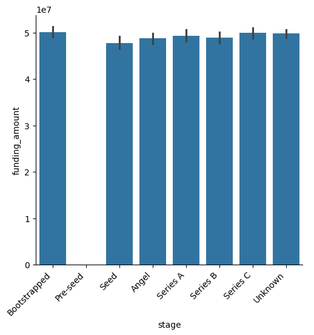

```python
sns.catplot(x="stage",y="funding_amount",data=df,kind="bar")
plt.xticks(rotation=45, ha='right')  # Rotate x-axis labels for readability
plt.show()
```

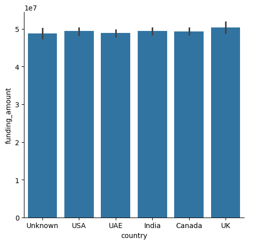

```python
sns.catplot(x="country",y="funding_amount",data=df,kind="bar")
plt.show()
```

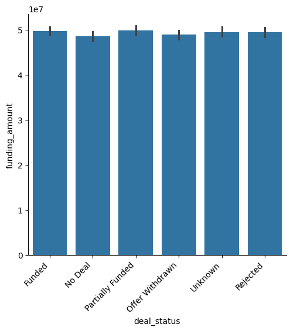

```python
sns.catplot(x="deal_status",y="funding_amount",data=df,kind="bar")
plt.xticks(rotation=45, ha='right')  # Rotate x-axis labels for readability
plt.show()
```

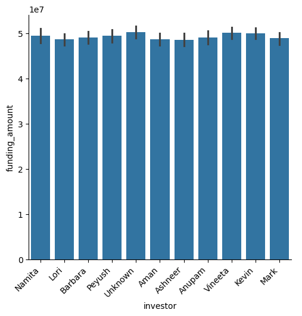

```python
sns.catplot(x="investor",y="funding_amount",data=df,kind="bar")
plt.xticks(rotation=45, ha='right')  # Rotate x-axis labels for readability
plt.show()
```

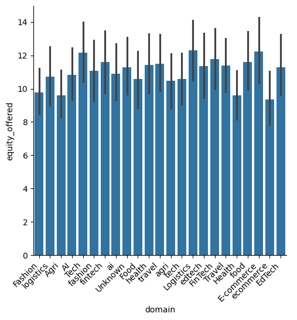

```python
sns.catplot(x="domain",y="equity_offered",data=df,kind="bar")
plt.xticks(rotation=45, ha='right')  # Rotate x-axis labels for readability
plt.show()
```

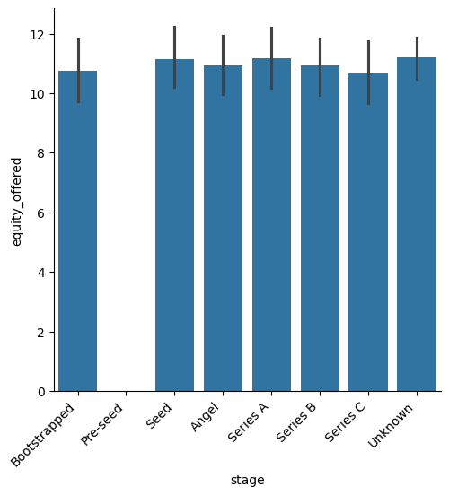

```python
sns.catplot(x="stage",y="equity_offered",data=df,kind="bar")
plt.xticks(rotation=45, ha='right')  # Rotate x-axis labels for readability
plt.show()
```

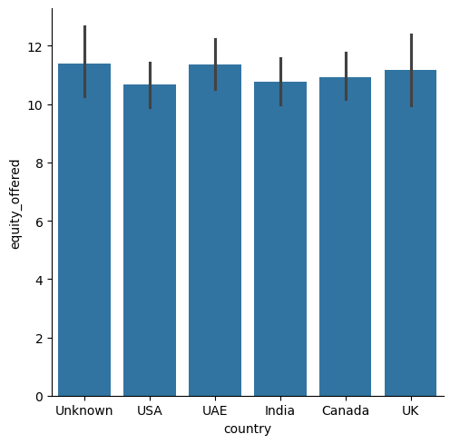

```python
sns.catplot(x="country",y="equity_offered",data=df,kind="bar")
plt.show()
```

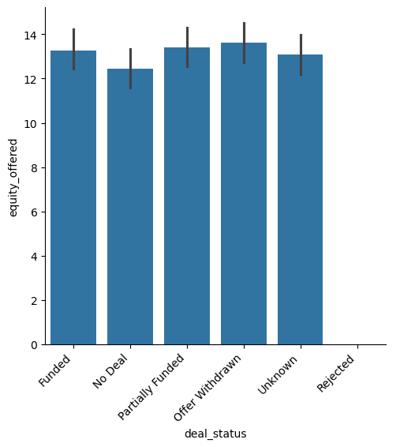

```python
sns.catplot(x="deal_status",y="equity_offered",data=df,kind="bar")
plt.xticks(rotation=45, ha='right')  # Rotate x-axis labels for readability
plt.show()
```

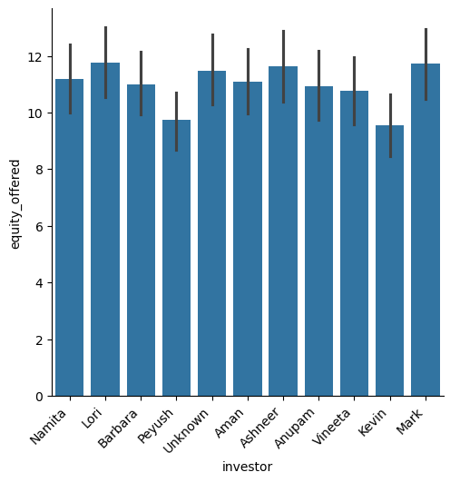

```python
sns.catplot(x="investor",y="equity_offered",data=df,kind="bar")
plt.xticks(rotation=45, ha='right')  # Roequity_offeredtate x-axis labels for readability
plt.show()
```

# Heat Map

- A heat map in Python is a graphical representation of data where values are depicted using colors

```python
hm = df[["funding_amount","equity_offered"]].corr()
hm
```

|  | funding_amount | equity_offered |
| --- | --- | --- |
| funding_amount | 1 | -0 |
| equity_offered | -0 | 1 |

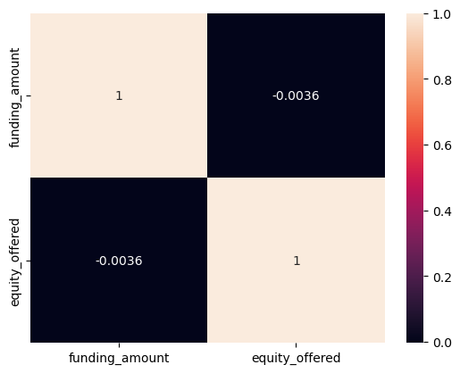

```python
sns.heatmap(hm,annot=True)
plt.show()
```

# Multivariate Measures

- correlation (All Continuous variable)
- crosstab (All discrete variable)
- groupby (2 discrete + 1 continous)

**Crosstab**

```python
pd.crosstab([df['investor'], df['stage']], df['domain'],margins = True).head(20)
```

| investor | domain stage | AI | Agri | EdTech | E‑commerce | Fashion | FinTech | Food | Health | Logistics | Tech | ... | ecommerce | edtech | fashion | fintech | food | health | logistics | tech | travel | All |
| --- | --- | --- | --- | --- | --- | --- | --- | --- | --- | --- | --- | --- | --- | --- | --- | --- | --- | --- | --- | --- | --- | --- |
| Aman | Bootstrapped | 2 | 2 | 4 | 3 | 3 | 4 | 2 | 3 | 1 | 2 | ... | 2 | 2 | 0 | 3 | 1 | 1 | 1 | 1 | 0 | 49 |
|  | Seed | 3 | 3 | 1 | 3 | 4 | 1 | 0 | 2 | 1 | 1 | ... | 0 | 1 | 2 | 0 | 2 | 4 | 1 | 1 | 5 | 40 |
|  | Angel | 1 | 1 | 1 | 0 | 1 | 5 | 2 | 3 | 7 | 3 | ... | 2 | 1 | 5 | 3 | 5 | 3 | 3 | 3 | 1 | 67 |
|  | Series A | 2 | 2 | 2 | 2 | 2 | 2 | 1 | 1 | 2 | 6 | ... | 5 | 2 | 2 | 6 | 1 | 6 | 4 | 5 | 3 | 63 |
|  | Series B | 1 | 0 | 1 | 2 | 5 | 1 | 6 | 1 | 4 | 2 | ... | 0 | 2 | 2 | 5 | 5 | 2 | 1 | 5 | 3 | 60 |
|  | Series C | 3 | 5 | 0 | 0 | 2 | 1 | 4 | 1 | 4 | 3 | ... | 2 | 3 | 1 | 1 | 2 | 2 | 2 | 5 | 2 | 53 |
|  | Unknown | 3 | 6 | 7 | 1 | 4 | 8 | 2 | 2 | 9 | 1 | ... | 7 | 6 | 8 | 3 | 5 | 3 | 2 | 11 | 5 | 117 |
| Anupam | Bootstrapped | 0 | 3 | 2 | 4 | 5 | 3 | 0 | 1 | 1 | 5 | ... | 3 | 4 | 1 | 2 | 0 | 4 | 2 | 3 | 2 | 54 |
|  | Seed | 2 | 3 | 1 | 3 | 2 | 0 | 4 | 1 | 2 | 3 | ... | 3 | 3 | 5 | 3 | 1 | 3 | 4 | 2 | 1 | 55 |
|  | Angel | 1 | 3 | 3 | 4 | 4 | 3 | 2 | 2 | 1 | 2 | ... | 4 | 1 | 3 | 2 | 0 | 3 | 1 | 3 | 2 | 56 |
|  | Series A | 3 | 4 | 1 | 5 | 2 | 2 | 2 | 4 | 2 | 1 | ... | 1 | 2 | 0 | 2 | 2 | 3 | 1 | 1 | 4 | 54 |
|  | Series B | 5 | 1 | 1 | 4 | 0 | 1 | 1 | 3 | 2 | 5 | ... | 0 | 3 | 3 | 2 | 2 | 2 | 4 | 1 | 3 | 55 |
|  | Series C | 2 | 2 | 0 | 1 | 2 | 3 | 2 | 1 | 0 | 3 | ... | 1 | 0 | 1 | 2 | 2 | 3 | 5 | 4 | 2 | 53 |
|  | Unknown | 4 | 11 | 6 | 6 | 3 | 5 | 0 | 1 | 7 | 4 | ... | 2 | 4 | 4 | 4 | 6 | 4 | 7 | 5 | 2 | 105 |
| Ashneer | Bootstrapped | 1 | 5 | 3 | 2 | 1 | 5 | 2 | 2 | 5 | 1 | ... | 2 | 3 | 2 | 1 | 4 | 3 | 3 | 0 | 1 | 63 |
|  | Seed | 2 | 3 | 4 | 1 | 5 | 0 | 3 | 2 | 2 | 3 | ... | 6 | 3 | 3 | 1 | 2 | 4 | 1 | 3 | 1 | 61 |
|  | Angel | 2 | 3 | 0 | 3 | 3 | 4 | 2 | 5 | 3 | 4 | ... | 3 | 3 | 4 | 1 | 2 | 2 | 1 | 3 | 3 | 61 |
|  | Series A | 3 | 4 | 1 | 5 | 0 | 1 | 2 | 1 | 2 | 3 | ... | 3 | 4 | 3 | 1 | 5 | 4 | 3 | 4 | 3 | 56 |
|  | Series B | 0 | 2 | 3 | 2 | 5 | 2 | 5 | 1 | 1 | 8 | ... | 2 | 1 | 1 | 3 | 0 | 1 | 3 | 5 | 1 | 57 |
|  | Series C | 5 | 1 | 1 | 0 | 2 | 1 | 3 | 3 | 1 | 3 | ... | 1 | 4 | 1 | 1 | 3 | 4 | 1 | 3 | 1 | 48 |

20 rows × 24 columns

```python
pd.crosstab([df['investor'], df['deal_status']], df['country'],margins = True).head(20)
```

| investor | country deal_status | Canada | India | UAE | UK | USA | Unknown | All |
| --- | --- | --- | --- | --- | --- | --- | --- | --- |
| Aman | Funded | 17 | 18 | 14 | 6 | 14 | 7 | 76 |
|  | No Deal | 12 | 19 | 10 | 7 | 13 | 14 | 75 |
|  | Offer Withdrawn | 13 | 18 | 17 | 4 | 14 | 7 | 73 |
|  | Partially Funded | 18 | 16 | 11 | 6 | 15 | 9 | 75 |
|  | Rejected | 17 | 9 | 25 | 9 | 11 | 8 | 79 |
|  | Unknown | 15 | 6 | 12 | 9 | 17 | 12 | 71 |
| Anupam | Funded | 14 | 16 | 19 | 4 | 18 | 3 | 74 |
|  | No Deal | 14 | 13 | 13 | 7 | 11 | 9 | 67 |
|  | Offer Withdrawn | 8 | 19 | 17 | 8 | 15 | 9 | 76 |
|  | Partially Funded | 14 | 17 | 16 | 3 | 13 | 4 | 67 |
|  | Rejected | 22 | 17 | 17 | 6 | 13 | 5 | 80 |
|  | Unknown | 18 | 16 | 12 | 6 | 13 | 3 | 68 |
| Ashneer | Funded | 21 | 19 | 17 | 8 | 17 | 6 | 88 |
|  | No Deal | 11 | 17 | 17 | 6 | 14 | 6 | 71 |
|  | Offer Withdrawn | 16 | 20 | 20 | 11 | 14 | 8 | 89 |
|  | Partially Funded | 14 | 21 | 14 | 10 | 8 | 5 | 72 |
|  | Rejected | 9 | 14 | 17 | 8 | 17 | 9 | 74 |
|  | Unknown | 19 | 11 | 10 | 5 | 14 | 10 | 69 |
| Barbara | Funded | 18 | 27 | 15 | 10 | 15 | 3 | 88 |
|  | No Deal | 9 | 19 | 17 | 6 | 20 | 9 | 80 |

**GroupBy**

```python
df.groupby(["domain","startup_name"])["funding_amount"].describe().T
```

| domain startup_name | AI AIBox_1855 | AI AICore_4377 | AI AIFoods_3074 | AI AIGen_2246 | AI AIGen_998 | AI AIHive_2493 | AI AIHive_468 | AI AIHub_1160 | AI AIHub_268 | AI AILabs_2188 | ... | travel UrbanBox_2008 | travel UrbanFoods_1781 | travel UrbanGen_1929 | travel UrbanKart_17 | travel UrbanLink_2263 | travel UrbanLink_4348 | travel UrbanSpark_1483 | travel UrbanWave_2249 | travel UrbanWave_3209 | travel UrbanWave_4093 |
| --- | --- | --- | --- | --- | --- | --- | --- | --- | --- | --- | --- | --- | --- | --- | --- | --- | --- | --- | --- | --- | --- |
| count | 1 | 1 | 1 | 1 | 1 | 1 | 1 | 1 | 1 | 1 | ... | 1 | 1 | 1 | 1 | 1 | 1 | 1 | 1 | 1 | 1 |
| mean | 32,617,072 | 49,114,685 | 49,114,685 | 46,043,710 | 49,114,685 | 49,114,685 | 49,114,685 | 49,114,685 | 77,600,972 | 49,114,685 | ... | 50,449,996 | 49,114,685 | 49,114,685 | 49,114,685 | 49,114,685 | 49,114,685 | 49,114,685 | 72,590,023 | 49,114,685 | 49,114,685 |
| std | NaN | NaN | NaN | NaN | NaN | NaN | NaN | NaN | NaN | NaN | ... | NaN | NaN | NaN | NaN | NaN | NaN | NaN | NaN | NaN | NaN |
| min | 32,617,072 | 49,114,685 | 49,114,685 | 46,043,710 | 49,114,685 | 49,114,685 | 49,114,685 | 49,114,685 | 77,600,972 | 49,114,685 | ... | 50,449,996 | 49,114,685 | 49,114,685 | 49,114,685 | 49,114,685 | 49,114,685 | 49,114,685 | 72,590,023 | 49,114,685 | 49,114,685 |
| 25% | 32,617,072 | 49,114,685 | 49,114,685 | 46,043,710 | 49,114,685 | 49,114,685 | 49,114,685 | 49,114,685 | 77,600,972 | 49,114,685 | ... | 50,449,996 | 49,114,685 | 49,114,685 | 49,114,685 | 49,114,685 | 49,114,685 | 49,114,685 | 72,590,023 | 49,114,685 | 49,114,685 |
| 50% | 32,617,072 | 49,114,685 | 49,114,685 | 46,043,710 | 49,114,685 | 49,114,685 | 49,114,685 | 49,114,685 | 77,600,972 | 49,114,685 | ... | 50,449,996 | 49,114,685 | 49,114,685 | 49,114,685 | 49,114,685 | 49,114,685 | 49,114,685 | 72,590,023 | 49,114,685 | 49,114,685 |
| 75% | 32,617,072 | 49,114,685 | 49,114,685 | 46,043,710 | 49,114,685 | 49,114,685 | 49,114,685 | 49,114,685 | 77,600,972 | 49,114,685 | ... | 50,449,996 | 49,114,685 | 49,114,685 | 49,114,685 | 49,114,685 | 49,114,685 | 49,114,685 | 72,590,023 | 49,114,685 | 49,114,685 |
| max | 32,617,072 | 49,114,685 | 49,114,685 | 46,043,710 | 49,114,685 | 49,114,685 | 49,114,685 | 49,114,685 | 77,600,972 | 49,114,685 | ... | 50,449,996 | 49,114,685 | 49,114,685 | 49,114,685 | 49,114,685 | 49,114,685 | 49,114,685 | 72,590,023 | 49,114,685 | 49,114,685 |

8 rows × 5000 columns

```python
df.groupby(["country","stage"])["funding_amount"].describe().T
```

| country stage | Canada Bootstrapped | Canada Seed | Canada Angel | Canada Series A | Canada Series B | Canada Series C | Canada Unknown | India Bootstrapped | India Seed | India Angel | ... | USA Series B | USA Series C | USA Unknown | Unknown Bootstrapped | Unknown Seed | Unknown Angel | Unknown Series A | Unknown Series B | Unknown Series C | Unknown |
| --- | --- | --- | --- | --- | --- | --- | --- | --- | --- | --- | --- | --- | --- | --- | --- | --- | --- | --- | --- | --- | --- |
| count | 114 | 126 | 125 | 131 | 129 | 109 | 270 | 138 | 137 | 133 | ... | 126 | 119 | 252 | 66 | 50 | 62 | 68 | 66 | 63 | 125 |
| mean | 50,483,957 | 48,289,632 | 48,280,406 | 50,645,491 | 49,595,308 | 50,651,185 | 48,603,186 | 50,343,995 | 47,917,575 | 49,415,292 | ... | 48,339,685 | 50,492,489 | 50,074,470 | 49,605,938 | 47,782,361 | 47,398,064 | 49,604,391 | 45,038,645 | 50,764,363 | 50,145,439 |
| std | 15,271,681 | 15,821,424 | 12,487,087 | 16,166,228 | 14,537,067 | 12,496,254 | 13,787,950 | 13,687,786 | 13,936,520 | 14,385,062 | ... | 14,848,924 | 16,042,652 | 16,651,539 | 13,834,996 | 20,473,510 | 11,741,256 | 15,149,685 | 16,154,468 | 12,311,679 | 15,250,637 |
| min | 2,724,499 | 4,569,938 | 1,663,836 | 813,173 | 4,663,470 | 911,229 | 498,126 | 8,704,271 | 629,910 | 19,089 | ... | 998,303 | 128,510 | 285,251 | 955,459 | 2,858,575 | 223,111 | 3,330,980 | 1,032,192 | 25,233,047 | 1,109,150 |
| 25% | 49,114,685 | 49,114,685 | 49,114,685 | 49,114,685 | 49,114,685 | 49,114,685 | 49,114,685 | 49,114,685 | 49,114,685 | 49,114,685 | ... | 49,114,685 | 49,114,685 | 49,114,685 | 49,114,685 | 49,114,685 | 49,114,685 | 49,114,685 | 49,114,685 | 49,114,685 | 49,114,685 |
| 50% | 49,114,685 | 49,114,685 | 49,114,685 | 49,114,685 | 49,114,685 | 49,114,685 | 49,114,685 | 49,114,685 | 49,114,685 | 49,114,685 | ... | 49,114,685 | 49,114,685 | 49,114,685 | 49,114,685 | 49,114,685 | 49,114,685 | 49,114,685 | 49,114,685 | 49,114,685 | 49,114,685 |
| 75% | 49,114,685 | 49,114,685 | 49,114,685 | 49,114,685 | 49,114,685 | 49,114,685 | 49,114,685 | 49,114,685 | 49,114,685 | 49,114,685 | ... | 49,114,685 | 49,114,685 | 49,114,685 | 49,114,685 | 49,114,685 | 49,114,685 | 49,114,685 | 49,114,685 | 49,114,685 | 49,114,685 |
| max | 99,474,284 | 98,502,738 | 99,202,099 | 99,698,789 | 96,093,502 | 99,948,211 | 98,783,538 | 98,115,705 | 98,569,476 | 99,707,818 | ... | 95,567,943 | 98,645,015 | 98,037,033 | 85,528,317 | 98,624,574 | 90,930,924 | 89,855,778 | 97,853,918 | 96,469,021 | 99,223,531 |

8 rows × 42 columns

```python
df.groupby(["deal_status","investor"])["funding_amount"].describe().T
```

| deal_status investor | Funded Aman | Funded Anupam | Funded Ashneer | Funded Barbara | Funded Kevin | Funded Lori | Funded Mark | Funded Namita | Funded Peyush | Funded Unknown | ... | Unknown Anupam | Unknown Ashneer | Unknown Barbara | Unknown Kevin | Unknown Lori | Unknown Mark | Unknown Namita | Unknown Peyush | Unknown | Unknown Vineeta |
| --- | --- | --- | --- | --- | --- | --- | --- | --- | --- | --- | --- | --- | --- | --- | --- | --- | --- | --- | --- | --- | --- |
| count | 76 | 74 | 88 | 88 | 77 | 72 | 84 | 79 | 74 | 80 | ... | 68 | 69 | 90 | 69 | 94 | 72 | 66 | 82 | 72 | 69 |
| mean | 49,379,865 | 51,608,236 | 47,605,022 | 49,701,772 | 49,888,751 | 50,229,454 | 48,093,564 | 47,475,224 | 48,789,900 | 51,182,027 | ... | 49,029,124 | 49,509,529 | 47,757,197 | 49,218,686 | 52,208,841 | 47,553,314 | 53,076,048 | 50,530,336 | 50,703,826 | 48,739,092 |
| std | 17,461,631 | 11,994,732 | 16,107,187 | 16,867,809 | 13,750,689 | 11,711,124 | 11,706,125 | 15,647,048 | 13,987,849 | 12,630,105 | ... | 15,560,859 | 12,764,758 | 16,673,793 | 14,826,247 | 12,243,509 | 16,176,552 | 17,665,632 | 12,649,509 | 13,117,650 | 19,518,139 |
| min | 1,810,637 | 12,502,745 | 1,958,965 | 203,969 | 4,013,574 | 177,420 | 6,075,980 | 3,633,936 | 9,331,381 | 9,207,152 | ... | 9,268,375 | 1,578,179 | 1,286,894 | 12,666,524 | 19,150,041 | 3,546,948 | 1,109,150 | 9,730,373 | 18,688,000 | 19,089 |
| 25% | 49,114,685 | 49,114,685 | 49,114,685 | 49,114,685 | 49,114,685 | 49,114,685 | 49,114,685 | 49,114,685 | 49,114,685 | 49,114,685 | ... | 49,114,685 | 49,114,685 | 49,114,685 | 49,114,685 | 49,114,685 | 49,114,685 | 49,114,685 | 49,114,685 | 49,114,685 | 49,114,685 |
| 50% | 49,114,685 | 49,114,685 | 49,114,685 | 49,114,685 | 49,114,685 | 49,114,685 | 49,114,685 | 49,114,685 | 49,114,685 | 49,114,685 | ... | 49,114,685 | 49,114,685 | 49,114,685 | 49,114,685 | 49,114,685 | 49,114,685 | 49,114,685 | 49,114,685 | 49,114,685 | 49,114,685 |
| 75% | 49,114,685 | 49,114,685 | 49,114,685 | 49,114,685 | 49,114,685 | 49,114,685 | 49,114,685 | 49,114,685 | 49,114,685 | 49,114,685 | ... | 49,114,685 | 49,114,685 | 49,114,685 | 49,114,685 | 49,114,685 | 49,114,685 | 49,114,685 | 49,114,685 | 49,114,685 | 49,114,685 |
| max | 98,829,135 | 96,358,130 | 97,039,592 | 99,674,401 | 99,965,336 | 99,948,211 | 90,358,929 | 99,200,937 | 98,669,891 | 99,223,531 | ... | 99,707,818 | 98,190,264 | 98,783,538 | 99,698,789 | 96,071,722 | 98,115,705 | 97,772,241 | 88,967,878 | 95,710,025 | 97,657,793 |

8 rows × 66 columns

```python
df.groupby(["domain","startup_name"])["equity_offered"].describe().T
```

| domain startup_name | AI AIBox_1855 | AI AICore_4377 | AI AIFoods_3074 | AI AIGen_2246 | AI AIGen_998 | AI AIHive_2493 | AI AIHive_468 | AI AIHub_1160 | AI AIHub_268 | AI AILabs_2188 | ... | travel UrbanBox_2008 | travel UrbanFoods_1781 | travel UrbanGen_1929 | travel UrbanKart_17 | travel UrbanLink_2263 | travel UrbanLink_4348 | travel UrbanSpark_1483 | travel UrbanWave_2249 | travel UrbanWave_3209 | travel UrbanWave_4093 |
| --- | --- | --- | --- | --- | --- | --- | --- | --- | --- | --- | --- | --- | --- | --- | --- | --- | --- | --- | --- | --- | --- |
| count | 1 | 1 | 1 | 1 | 1 | 1 | 1 | 1 | 1 | 1 | ... | 1 | 1 | 1 | 1 | 1 | 1 | 1 | 1 | 1 | 1 |
| mean | 7 | 7 | 7 | 7 | 13 | 7 | 31 | 7 | 7 | 0 | ... | 60 | 18 | 7 | 26 | 7 | 52 | 7 | 7 | 0 | 7 |
| std | NaN | NaN | NaN | NaN | NaN | NaN | NaN | NaN | NaN | NaN | ... | NaN | NaN | NaN | NaN | NaN | NaN | NaN | NaN | NaN | NaN |
| min | 7 | 7 | 7 | 7 | 13 | 7 | 31 | 7 | 7 | 0 | ... | 60 | 18 | 7 | 26 | 7 | 52 | 7 | 7 | 0 | 7 |
| 25% | 7 | 7 | 7 | 7 | 13 | 7 | 31 | 7 | 7 | 0 | ... | 60 | 18 | 7 | 26 | 7 | 52 | 7 | 7 | 0 | 7 |
| 50% | 7 | 7 | 7 | 7 | 13 | 7 | 31 | 7 | 7 | 0 | ... | 60 | 18 | 7 | 26 | 7 | 52 | 7 | 7 | 0 | 7 |
| 75% | 7 | 7 | 7 | 7 | 13 | 7 | 31 | 7 | 7 | 0 | ... | 60 | 18 | 7 | 26 | 7 | 52 | 7 | 7 | 0 | 7 |
| max | 7 | 7 | 7 | 7 | 13 | 7 | 31 | 7 | 7 | 0 | ... | 60 | 18 | 7 | 26 | 7 | 52 | 7 | 7 | 0 | 7 |

8 rows × 5000 columns

```python
df.groupby(["country","stage"])["equity_offered"].describe().T
```

| country stage | Canada Bootstrapped | Canada Seed | Canada Angel | Canada Series A | Canada Series B | Canada Series C | Canada Unknown | India Bootstrapped | India Seed | India Angel | ... | USA Series B | USA Series C | USA Unknown | Unknown Bootstrapped | Unknown Seed | Unknown Angel | Unknown Series A | Unknown Series B | Unknown Series C | Unknown |
| --- | --- | --- | --- | --- | --- | --- | --- | --- | --- | --- | --- | --- | --- | --- | --- | --- | --- | --- | --- | --- | --- |
| count | 114 | 126 | 125 | 131 | 129 | 109 | 270 | 138 | 137 | 133 | ... | 126 | 119 | 252 | 66 | 50 | 62 | 68 | 66 | 63 | 125 |
| mean | 9 | 10 | 11 | 11 | 10 | 12 | 12 | 10 | 11 | 11 | ... | 13 | 9 | 10 | 14 | 13 | 9 | 13 | 10 | 9 | 12 |
| std | 10 | 11 | 13 | 12 | 12 | 14 | 14 | 11 | 13 | 13 | ... | 15 | 12 | 11 | 16 | 15 | 10 | 15 | 12 | 10 | 15 |
| min | 0 | 0 | 0 | 0 | 0 | 0 | 0 | 0 | 0 | 0 | ... | 0 | 0 | 0 | 0 | 0 | 0 | 0 | 0 | 0 | 0 |
| 25% | 7 | 7 | 7 | 7 | 7 | 7 | 7 | 7 | 7 | 7 | ... | 7 | 7 | 7 | 7 | 7 | 7 | 7 | 7 | 7 | 7 |
| 50% | 7 | 7 | 7 | 7 | 7 | 7 | 7 | 7 | 7 | 7 | ... | 7 | 7 | 7 | 7 | 7 | 7 | 7 | 7 | 7 | 7 |
| 75% | 7 | 7 | 7 | 7 | 7 | 7 | 7 | 7 | 7 | 7 | ... | 7 | 7 | 7 | 15 | 10 | 7 | 11 | 7 | 7 | 7 |
| max | 51 | 53 | 59 | 58 | 53 | 59 | 59 | 57 | 56 | 60 | ... | 59 | 57 | 58 | 58 | 59 | 55 | 57 | 57 | 48 | 59 |

8 rows × 42 columns

```python
df.groupby(["deal_status","investor"])["equity_offered"].describe().T
```

| deal_status investor | Funded Aman | Funded Anupam | Funded Ashneer | Funded Barbara | Funded Kevin | Funded Lori | Funded Mark | Funded Namita | Funded Peyush | Funded Unknown | ... | Unknown Anupam | Unknown Ashneer | Unknown Barbara | Unknown Kevin | Unknown Lori | Unknown Mark | Unknown Namita | Unknown Peyush | Unknown | Unknown Vineeta |
| --- | --- | --- | --- | --- | --- | --- | --- | --- | --- | --- | --- | --- | --- | --- | --- | --- | --- | --- | --- | --- | --- |
| count | 76 | 74 | 88 | 88 | 77 | 72 | 84 | 79 | 74 | 80 | ... | 68 | 69 | 90 | 69 | 94 | 72 | 66 | 82 | 72 | 69 |
| mean | 14 | 12 | 14 | 14 | 11 | 12 | 14 | 16 | 10 | 15 | ... | 13 | 13 | 13 | 11 | 13 | 13 | 14 | 16 | 13 | 12 |
| std | 13 | 12 | 14 | 14 | 9 | 12 | 14 | 16 | 9 | 16 | ... | 13 | 13 | 13 | 12 | 13 | 13 | 13 | 16 | 14 | 12 |
| min | 3 | 1 | 1 | 2 | 1 | 3 | 1 | 7 | 4 | 3 | ... | 2 | 7 | 5 | 2 | 2 | 1 | 4 | 5 | 1 | 2 |
| 25% | 7 | 7 | 7 | 7 | 7 | 7 | 7 | 7 | 7 | 7 | ... | 7 | 7 | 7 | 7 | 7 | 7 | 7 | 7 | 7 | 7 |
| 50% | 7 | 7 | 7 | 7 | 7 | 7 | 7 | 7 | 7 | 7 | ... | 7 | 7 | 7 | 7 | 7 | 7 | 7 | 7 | 7 | 7 |
| 75% | 17 | 7 | 10 | 7 | 7 | 7 | 17 | 20 | 7 | 8 | ... | 7 | 7 | 7 | 7 | 7 | 9 | 7 | 14 | 7 | 7 |
| max | 59 | 57 | 59 | 59 | 53 | 59 | 59 | 57 | 56 | 58 | ... | 55 | 56 | 60 | 58 | 59 | 57 | 57 | 59 | 58 | 54 |

8 rows × 66 columns